# Assignment 2018/05/08

Keiichi Takehana

2018/05/07

# 1 Re-read “Properties of matrices”, then describe “rank”, “determinant”, “trace” and “eigen values as you like, so that the description would be helpful for yourself a half year later. You can write in your mother tongue. In case the description is not in English or Japanese, do not anticipate feedback, though.

## 1.1 Rank

n個のp次元ベクトル$a_1, a_2, \cdots , a_n$ を列ベクトルとする$p \times n$の行列Aを考えると、この列ベクトルの中で1次独立な個数を行列Aのランクと呼ぶ。

あるn次元の線形空間VからV’の写像fを考える。この線形空間V上のベクトルに対して上の行列Aを掛けると、その変換後部分空間V’ = Im fはAの列ベクトルが張る空間上の点となる。

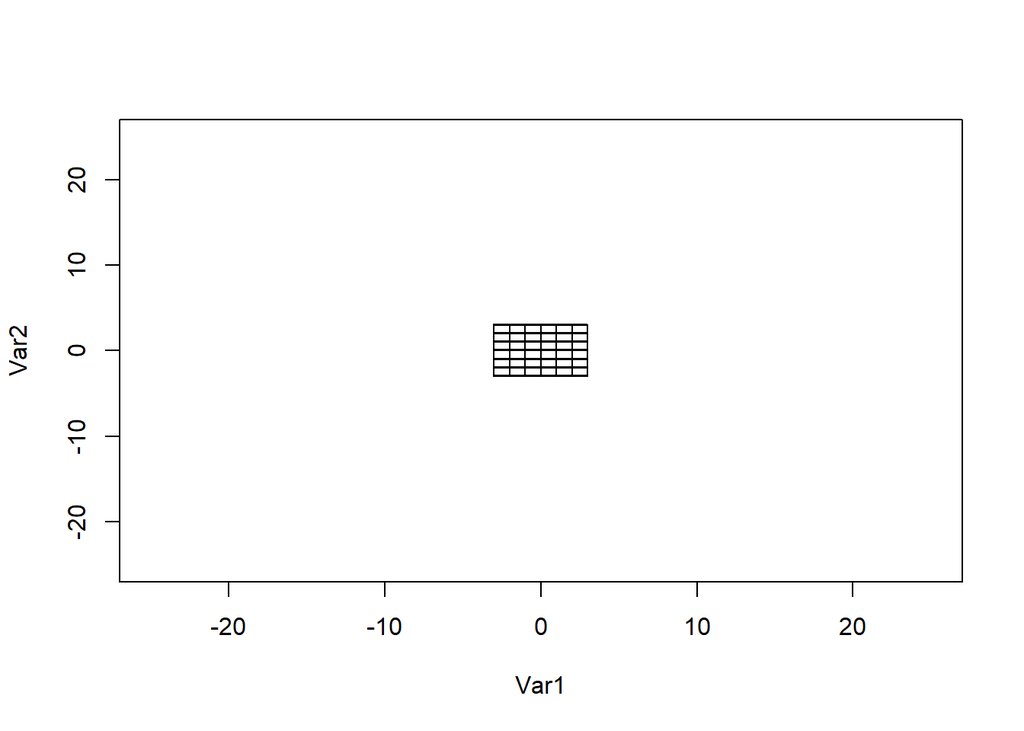

```r
library(Matrix)

x <- seq(-3,3,by=1)
y <- seq(-3,3,by=0.01)
x. <- numeric(length(x)^2)
y. <- numeric(length(y)^2)
grid <- rbind(expand.grid(x,y),expand.grid(y,x))
plot(grid,pch=20,cex=0.1,xlim=c(-25,25),ylim=c(-25,25))
```

```r
Mat_Rank2 = matrix(c(1, 1, 1, 2), 2, 2)
Mat_Rank1 = matrix(c(1, 2, 2, 4), 2, 2)
Mat_Rank0 = matrix(c(0, 0, 0, 0), 2, 2)
rankMatrix(Mat_Rank2)
```

```
## [1] 2
## attr(,"method")
## [1] "tolNorm2"
## attr(,"useGrad")
## [1] FALSE
## attr(,"tol")
## [1] 4.440892e-16
```

```r
rankMatrix(Mat_Rank1)
```

```
## [1] 1
## attr(,"method")
## [1] "tolNorm2"
## attr(,"useGrad")
## [1] FALSE
## attr(,"tol")
## [1] 4.440892e-16
```

```r
rankMatrix(Mat_Rank0)
```

```
## [1] 0
## attr(,"method")
## [1] "tolNorm2"
## attr(,"useGrad")
## [1] FALSE
## attr(,"tol")
## [1] 4.440892e-16
```

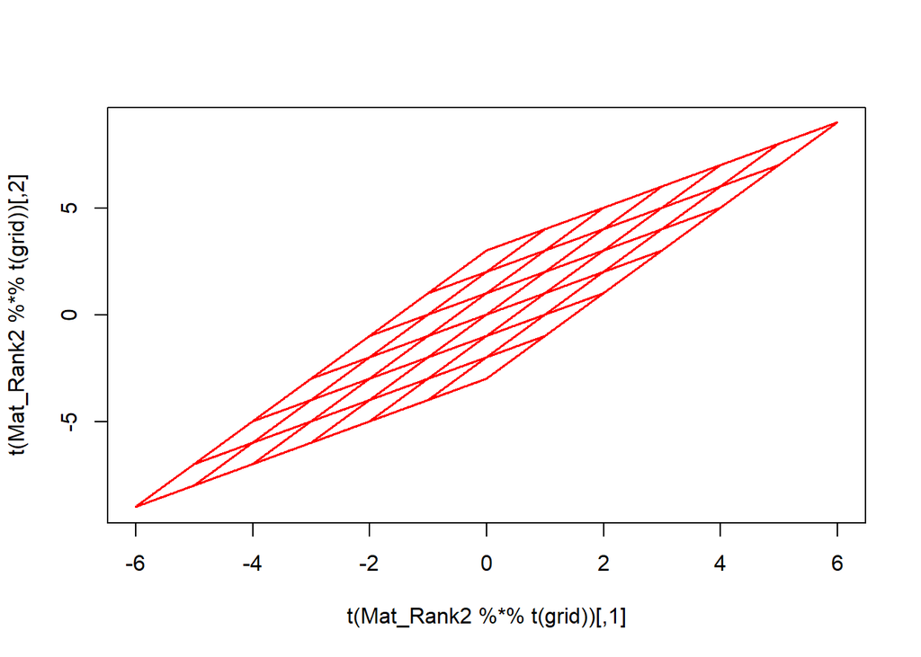

```r
plot(t(Mat_Rank2 %*% t(grid)), pch=20, cex=0.1, col = 2)
```

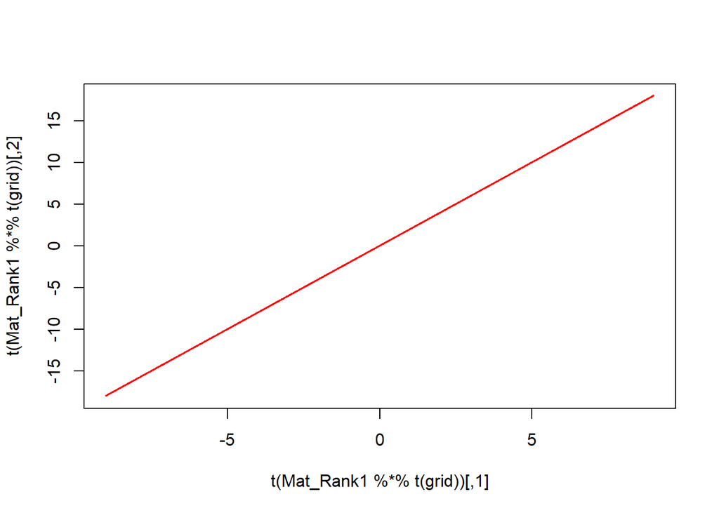

```r
plot(t(Mat_Rank1 %*% t(grid)), pch=20, cex=0.1, col = 2)
```

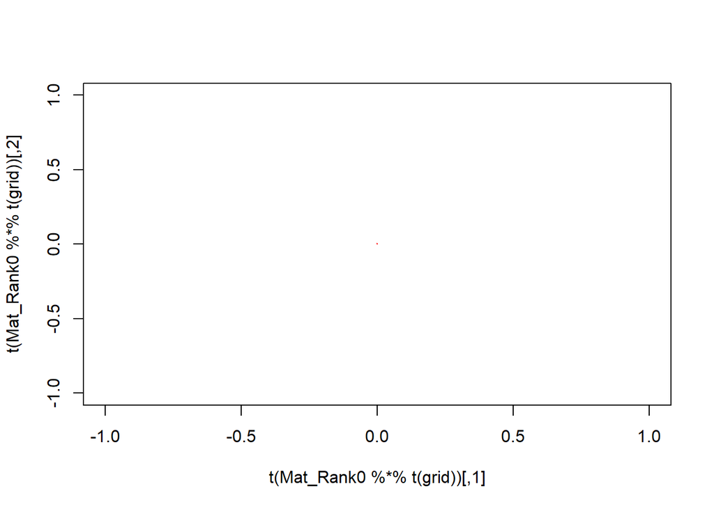

```r
plot(t(Mat_Rank0 %*% t(grid)), pch=20, cex=0.1, col = 2)
```

## 1.2 Determinant

定義は以下の式で表される。$\sigma$は置換を表す。
$$\det A=\displaystyle\sum_{\sigma\in S_n}\mathrm{sgn}(\sigma)\prod_{i=1}^na_{i\sigma(i)}$$

図形的な意味としては、 3次元上での行列Aを考えると、Aのそれぞれの列ベクトルがはる平行6面体の体積（符号付）と一致する（絶対値をとると体積に一致する）。2次元上では平行四辺形の面積（符号付）となる。

行列式が０の場合は逆行列が存在しない。また上記のベクトルが1次従属である（行列のRankが落ちる）場合は行列式が０となる。また1次従属に近い場合も行列式が０に近づくため、多変量解析などで逆行列を求めるときにわずかな数値の変化で大きく逆行列の値が変化する。これを多重共線性と呼ぶ。

## 1.3 Trace

n x nの正方行列に対してその対角成分の和をトレースといい、以下の性質がある。
$$1. tr(kA) = ktr(A) \\
2. tr(A+b) = tr(A) + tr(B) \\
3. tr(X^T) = tr(X) \\
4. tr(AB) = tr(BA) \\
5. tr(AB^T) =\displaystyle\sum_{i=1}^n\sum_{j=1}^na_{ij}b_{ij}$$

また
$$tr(A) = tr(P^{-1}PA) = tr(PAP^{-1})$$
であるので相似な変形似に対して不変である。

## 1.4 Eigen values

正方行列A, と0でないベクトル$\overrightarrow{x}$に対して、 $A\overrightarrow{x}=\lambda \overrightarrow{x}$ が成り立つときに$\overrightarrow{x}$をAの固有ベクトル、$\lambda$をAの固有値と呼ぶ。

Aをp次の正方行列とすると、p個の1次独立な固有ベクトルが存在するとき、固有ベクトルの組を基底としてとることによってAを対角化可能である。 線形変換行う際に固有ベクトル上の点はその固有ベクトルの方向の位置にとどまる（固有値を掛けた位置に移動する）。

Rankは0でない固有値の数 Determinantは固有値の積 Traceは固有値の和 であり、すべて固有値によって関連付けられる。

# 2 Linear model, “y=ax + b” can be considered as an affine transformation. Assume a transformation that moves a point (x,0) to (x,ax). Make a matrix that does the transformation. Then make a matrix that moves a point (x,0) to (x,ax+b). How about a matrix that moves (x1,x2,0) to (a1x1 + a2x2,b1x1+b2x2). Then a matrix that moves (x1,x2,0) to (a1x1+a2x2+c,b1x1+b2x2+d).

$$(x, 0) \rightarrow (x, ax) \\
M \times \begin{pmatrix}x \\ 0 \\ 1 \end{pmatrix} = \begin{pmatrix}x \\ ax \\ 1 \end{pmatrix}\\
M = \begin{pmatrix}1, 0, 0 \\ a, 0, 0 \\ 0, 0, 1 \end{pmatrix}$$

$$(x, 0) \rightarrow (x, ax + b) \\
M \times \begin{pmatrix}x \\ 0 \\ 1 \end{pmatrix} = \begin{pmatrix}x \\ ax + b \\ 1 \end{pmatrix}\\
M = \begin{pmatrix}1, 0, 0 \\ a, 0, b \\ 0, 0, 1 \end{pmatrix}$$

$$(x_1, x_2, 0) \rightarrow (a_1 x_1 + a_2 x_2, b_1 x_1 + b_2 x_2, 0) \\
M \times \begin{pmatrix}x_1 \\ x_2 \\ 0 \\ 1 \end{pmatrix} = \begin{pmatrix}a_1 x_1 + b_1 x_1 \\ a_2 x_2 + b_2 x_2 \\ 0 \\ 1 \end{pmatrix}\\
M = \begin{pmatrix}a_1, a_2, 0, c \\ b_1, b_2, 0, d \\ 0, 0, 0, 1 \end{pmatrix}$$